# XML Side Project

Group B XML Partners

June 9, 2019

# Intro to XML

Lets start to understand about *Extensible Markup Language*, or XML.

To put in simple terms, XML is used to **describe data**.

The XML language is useful for creating unique formats of data and electronically sharing structured data through the public internet and corporate networks.

The basic foundation of XML code is an *element*, defined by *tags*. If you are unsure what tags are, they are essentially lines of code starting with a beginning tag and ending with an ending tag:

<*beginning tag*> **Element** <*/ending tag*>.

## Benefits

XML is a good way to store data for several reasons.

1. XML is a very simple medium to store the data.
2. It can take large chunks of information and consolidate them into an XML document - meaning that it can effectively organize and provide structure to the user in understanding the data.
3. XML data is self-describing, meaning that the structure of the data is already embedded with the data. When the data arrives, there is no need to pre-build the structure of the data.

If you’re interested in learning more, please visit [this website](https://searchmicroservices.techtarget.com/definition/XML-Extensible-Markup-Language)!

## Description of Data

We have chosen a census dataset from the National Center for Health Statistics, that presents the age-adjusted death rates for the 10 leading causes of death in the US beginning in 1999. Age-adjusted death rates are (per 100,000 population) based on the 2000 US standard population.

This data enables us to identify health problems in different states, and mainly document the health status of the popluation and of important subgroups. Below, you can find some relevant analyses of our data.

## Package/functions used to read in xml data

We used XML package in R. XML package has bunch of useful functions for data read in and manipulation.  
1. xmlParse() comes from the XML package in R. It is used commonly to parse or analyze each component of an XML file. This helps to generate an R structure representing the XML tree.  
2. The xmlToDataframe() enables us to extract data from a simple xml document.  
3. The nodes option entails a list of XML nodes (components), which are to be processed. The getNodeSet() enables us to access a specific part of our xml file.

To learn more about XML package, click [here](https://cran.r-project.org/web/packages/XML/XML.pdf).

# Read/Manipulate Data

To begin reading in XML data, follow these steps:

1. Load in the XML package
2. Apply the xmlParse(“Path to file”) to begin reading in your XML file.
3. Grab a node/component from the file using xmlToDataframe
- This creates a dataframe of factors for each node read in.
4. Be Creative with how you manipulate your data!

```r
library(XML)
library(DT)
library(dplyr)
library(methods)
library(tidyverse)

xmlData <- xmlParse("http://data.cdc.gov/api/views/bi63-dtpu/rows.xml")

Y <- setNames(xmlToDataFrame(node=getNodeSet(xmlData, "//year")), "Year")
D <- setNames(xmlToDataFrame(node=getNodeSet(xmlData, "//cause_name")), "Cause")
De <- setNames(xmlToDataFrame(node=getNodeSet(xmlData, "//deaths")), "deaths")
S <- setNames(xmlToDataFrame(node=getNodeSet(xmlData, "//state")), "State")
A <- setNames(xmlToDataFrame(node=getNodeSet(xmlData, "//aadr")), "AADR")

xmlDataDf <- cbind(Y, D, De, S, A)
#creating a dataset

options(digits = 10)
#Create numeric variables
xmlDataDf$AADR <- as.numeric(as.character(xmlDataDf$AADR))
xmlDataDf$deaths <- as.numeric(as.character(xmlDataDf$deaths))
xmlDataDf$Year  <- as.numeric(as.character(xmlDataDf$Year))
# Create Character Variables
xmlDataDf$Cause <- as.character(xmlDataDf$Cause)
xmlDataDf$State <- as.character(xmlDataDf$State)

xmlDataDf2 <- xmlDataDf
str(xmlDataDf2)
```

```
## 'data.frame':    10296 obs. of  5 variables:
##  $ Year  : num  2012 2016 2013 2000 2014 ...
##  $ Cause : chr  "Kidney disease" "Kidney disease" "Kidney disease" "Suicide" ...
##  $ deaths: num  21 30 30 23 325 29 49 39 37 374 ...
##  $ State : chr  "Vermont" "Vermont" "Vermont" "District of Columbia" ...
##  $ AADR  : num  2.6 3.7 3.8 3.8 4.1 4.4 4.5 4.5 4.5 4.9 ...
```

# Summary Analyses

## 2010 Top 10 leading causes of Death in NC

This datatable presents the top 10 causes of Death in NC proportional to the total number of deaths in the United States. This is an important topic to discuss, because although the number of deaths itself is important, a proportion can give us more information about the deaths in the state of NC.

A larger proportion can tell us which causes are more affecting residents in NC, which can help us make decisions that benefit the majority of residents in NC suffering from these potential causes. Kidney disease has the highest proportion out of the top 10 causes of death in NC, so focusing on this can be a good step in the future in terms of health care.

Comparing National and State deaths

| Year | Causes | NC-Deaths | US-Deaths | NCtoUSRatio |
| --- | --- | --- | --- | --- |
| 2010 | Kidney disease | 1892 | 50476 | 0.03748 |
| 2010 | Unintentional injuries | 4144 | 120859 | 0.03429 |
| 2010 | Influenza and pneumonia | 1700 | 50097 | 0.03393 |
| 2010 | Alzheimer’s disease | 2817 | 83494 | 0.03374 |
| 2010 | Stroke | 4298 | 129476 | 0.03320 |
| 2010 | CLRD | 4495 | 138080 | 0.03255 |
| 2010 | Suicide | 1174 | 38364 | 0.03060 |
| 2010 | Heart disease | 18061 | 597689 | 0.03022 |
| 2010 | Cancer | 17154 | 574743 | 0.02985 |
| 2010 | Diabetes | 2042 | 69071 | 0.02956 |

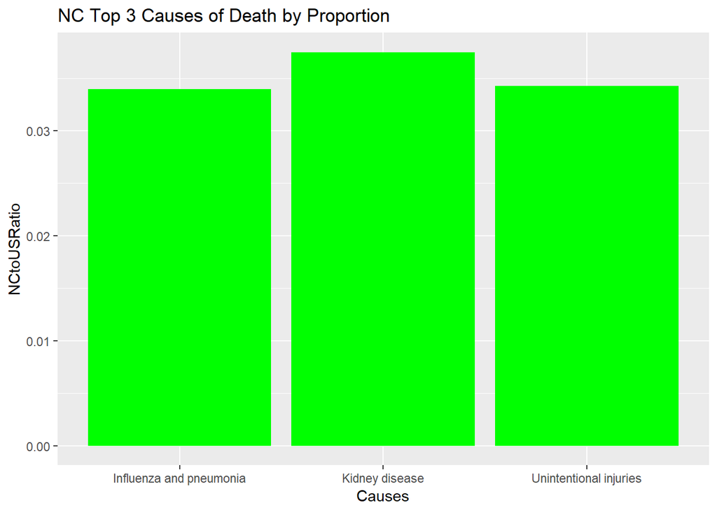

## Contingency Table

The Idea of this table is centered around how frequent the State of California will have more than 10k deaths within the 3 year period. The number 10k represents our threshold, which indicates if this is a cause that needs to be focused primarily on.

Heart disease, Cancer, and Chronic Lower Respiratory Disease (CLRD), each have 2 or more instances of having over 10k deaths. From this data, we can see that these might be the top 3 causes of death that would need major focus on. By devoting more time and money to these fields, we can help a majority of the population prevent and cure these causes.

Occurrences of causes in California with more/less than 10k deaths in 2008, 2010, 2012

|  | Over 10k deaths | Under 10k deaths |
| --- | --- | --- |
| Alzheimer’s disease | 1 | 2 |
| Cancer | 3 | 0 |
| CLRD | 2 | 1 |
| Diabetes | 0 | 3 |
| Heart disease | 3 | 0 |
| Influenza and pneumonia | 0 | 3 |
| Kidney disease | 0 | 3 |
| Stroke | 1 | 2 |
| Suicide | 0 | 3 |
| Unintentional injuries | 1 | 2 |

## Summary Statistics Table

In these analyses, we are focused on analyzing the 3 largest states and the top leading cause of death in those states, which is heart disease. These tables provide us with the measures of the mean, which in this case refers to the average number of deaths in 2008, 2010, and 2012, and more. We can also analyze the minimum and maximum of those values the deaths as well, and see that the rates of change for Texas and Florida are low, compared to California.

Summary of Heart Disease Deaths in CA through 3 years

|  | deaths |
| --- | --- |
| Min | 58641 |
| 1st Qu. | 59006 |
| Median | 59371 |
| 3rd Qu. | 60040 |
| Max | 60709 |
| Mean | 59574 |

Summary of Heart Disease Deaths in TX through 3 Years

|  | deaths |
| --- | --- |
| Min | 38253 |
| 1st Qu. | 38319 |
| Median | 38384 |
| 3rd Qu. | 38723 |
| Max | 39061 |
| Mean | 38566 |

Summary of Heart Disease Deaths in FL through 3 Years

|  | deaths |
| --- | --- |
| Min | 41737 |
| 1st Qu. | 41902 |
| Median | 42067 |
| 3rd Qu. | 42096 |
| Max | 42125 |
| Mean | 41976 |

## Graphical Representation of Data Analyses

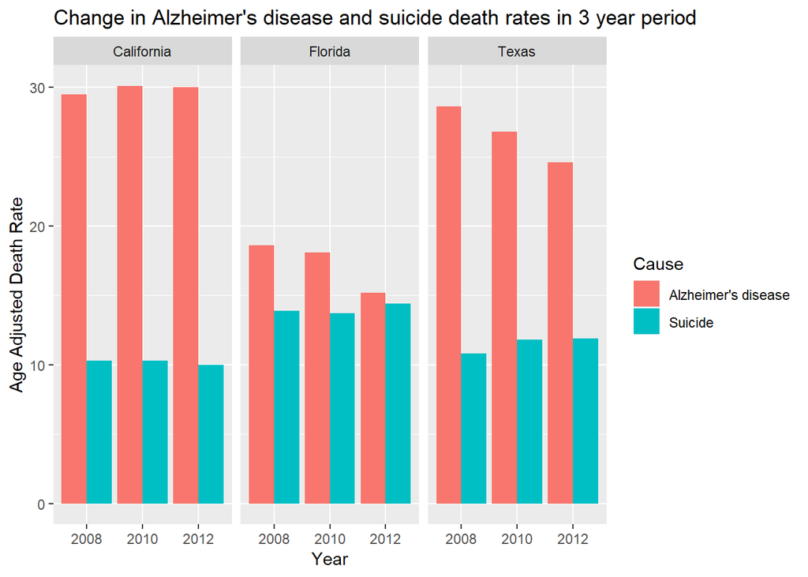

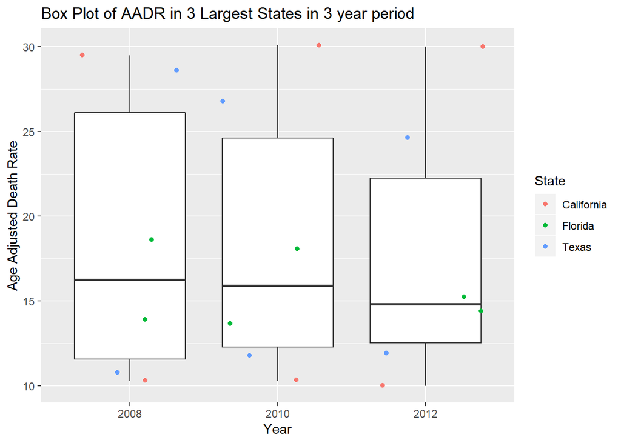

# Alternative way to read in data

We can also read in data straight from the internet!

```r
library(XML)
library(DT)
library(dplyr)
library(methods)
library(tidyverse)
#The xmlParse() comes from the XML package in R.
#This is used commonly to parse or analyze each component of an XML file.
#This helps to generate an R structure representing the XML tree.
xmlData <- xmlParse("http://data.cdc.gov/api/views/bi63-dtpu/rows.xml")
#extract xml data to dtatframe
year <- setNames(xmlToDataFrame(node=getNodeSet(xmlData, "//year")), "Year")
cause <- setNames(xmlToDataFrame(node=getNodeSet(xmlData, "//cause_name")), "Cause")
deaths <- setNames(xmlToDataFrame(node=getNodeSet(xmlData, "//deaths")), "Deaths")
state <- setNames(xmlToDataFrame(node=getNodeSet(xmlData, "//state")), "State")
aadr <- setNames(xmlToDataFrame(node=getNodeSet(xmlData, "//aadr")), "AADR")
xmlDataDfA <- cbind(year, cause, deaths, state, aadr)

options(digits = 10)
#Convert AADR, Deaths & Year to numeric variables
xmlDataDfA$AADR <- as.numeric(as.character(xmlDataDfA$AADR))
xmlDataDfA$Deaths <- as.numeric(as.character(xmlDataDfA$Deaths))
str(xmlDataDfA)
```

```
## 'data.frame':    10296 obs. of  5 variables:
##  $ Year  : Factor w/ 18 levels "1999","2000",..: 14 18 15 2 16 11 13 17 16 15 ...
##  $ Cause : Factor w/ 11 levels "All causes","Alzheimer's disease",..: 8 8 8 10 8 10 8 8 8 8 ...
##  $ Deaths: num  21 30 30 23 325 29 49 39 37 374 ...
##  $ State : Factor w/ 52 levels "Alabama","Alaska",..: 47 47 47 9 3 9 42 47 47 3 ...
##  $ AADR  : num  2.6 3.7 3.8 3.8 4.1 4.4 4.5 4.5 4.5 4.9 ...
```

# Plots Galore!

## Quantitative Data Analysis

The table provides us a summary of leading causes of deaths in Georgia between 2011 and 2016. It shows the total number of deaths and average age adjusted death rate for each cause. We can see that from this table, the average death ratio and average of total deaths are highly correlated.

Causes of Death in Georgia in Last 5 years (2011-2016)

| State | Cause | totalDeaths | avgAADR |
| --- | --- | --- | --- |
| Georgia | Suicide | 7558 | 12.33333333 |
| Georgia | Influenza and pneumonia | 8741 | 16.11666667 |
| Georgia | Kidney disease | 10322 | 18.50000000 |
| Georgia | Diabetes | 13086 | 22.35000000 |
| Georgia | Alzheimer’s disease | 16745 | 33.16666667 |
| Georgia | Unintentional injuries | 24251 | 41.10000000 |
| Georgia | Stroke | 23526 | 43.01666667 |
| Georgia | CLRD | 25730 | 45.88333333 |
| Georgia | Cancer | 98853 | 165.96666667 |
| Georgia | Heart disease | 101167 | 179.61666667 |

## Visual Summary - Quantitative

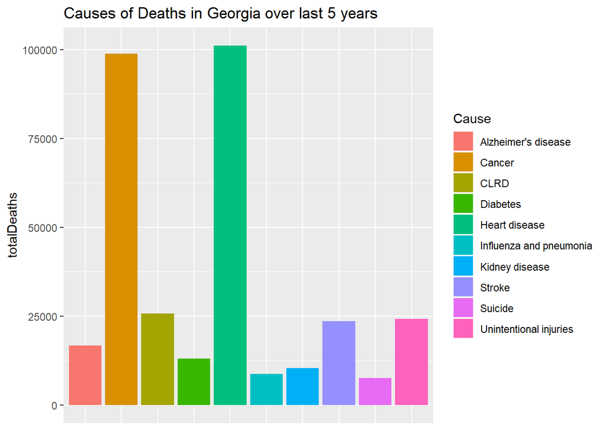

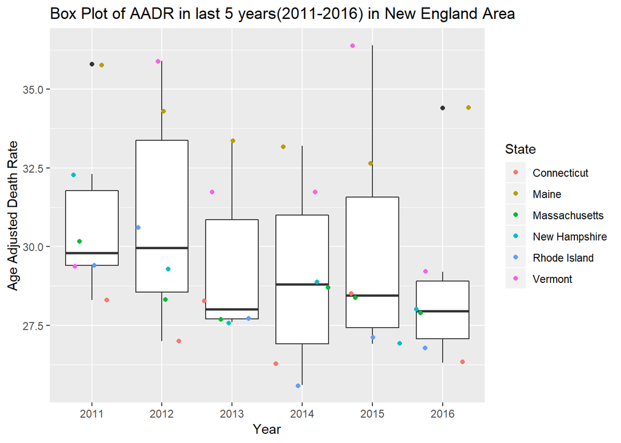